# Spatial data – the essential concepts

Pierre Roudier

2017-10-12

# The support of information

The support of information is the spatial artefact from which a meaasurement has been made, or from which a sample has been collected.

There are fundamentaly two doiffreent types of support for spatial data: vector and raster data.

## Vector data model

Vectors are essentially discrete geometries, or shapes.

There are different kind of vector support:

- points
- lines
- polygons

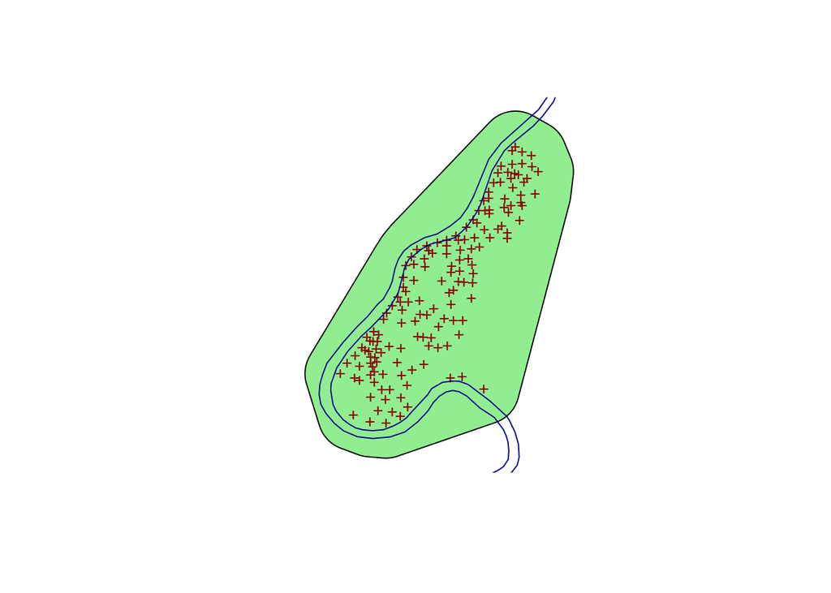

## Raster data model

The raster model, on the other hand, describes data based on a regularly-spaced matrix:

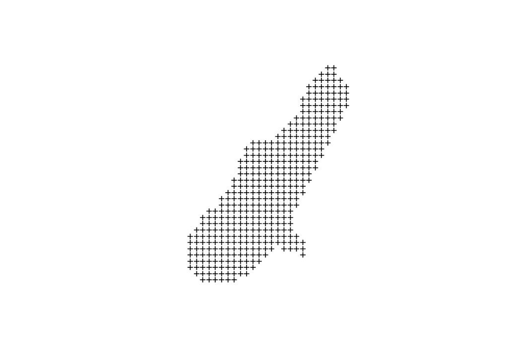

This means, in particular, that the **resolution** of that matrix (ie the distance between the centers of two pixels) is an important factor, relating to the scale of the phenomena that the data encodes.

The raster data model has become very popular due to the explosion of remotely-sensed data:

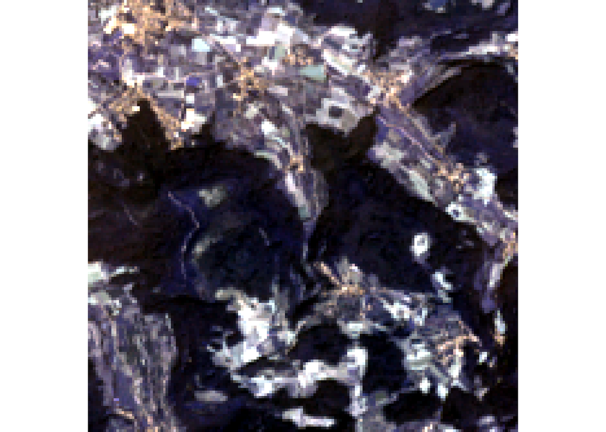

Often it is possible to go from raster to vector and back:

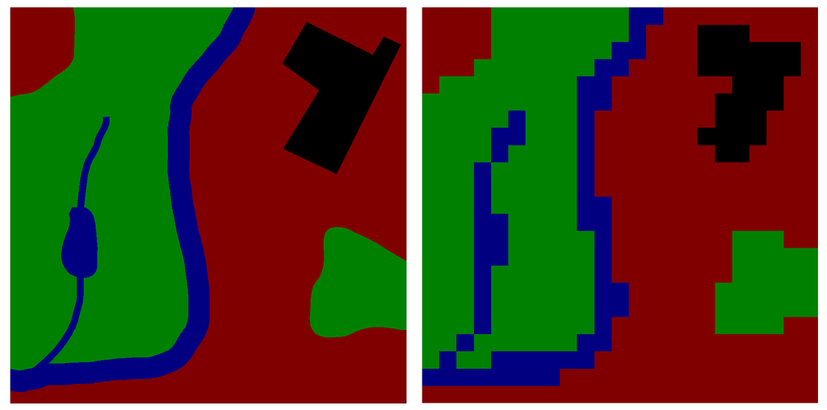

Illustration: Wikimedia

# Projected and unprojected data

## The way we collect spatial data

If we exclude the special case of remote sensing, data is often collected using a GPS unit, which essentially measure our position on Earth using **longitude** and **latitude**.

The system used as a reference for these observations is **WGS84**, the World Geodetic System, established in 1984 (and last revised in 2004). It is a collection of:

- A coordinate system originating at the Earth’s center of mass,
- A meridian zero,
- A datum, which is a surface that approximates the shape of the Earth,
- A geoid, that defines a reference sea level.

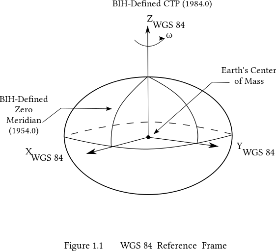

Illustration: Wikimedia

## Flat Earth

While latitude and longitude are great for data collection and navigation (because we live on a pseudosphere!), they are not ideal for data analysis! In particular:

- Distances along a pseudo-sphere are a lot harder to compute
- We generally represent data on 2D surface, whether it’s a computer screen or a map

So ideally, for data analysis, we would like to work in a 2-D plan.

# What it means in your daily GIS life

## Projection systems to the rescue

> A map projection is a systematic transformation of the latitudes and longitudes of locations from the surface of a sphere or an ellipsoid into locations on a plane.

Exactly what we need!

You can think of projectin systems as (generally local) mathematical formula that fold a sphere onto a plan.

They can have various properties (preserve shape, preserve area, preserve distance, etc.).

In New Zealand, we usually use the New Zealand Transverse Mercator 2000 projection (NZTM), whioch superseeded the New Zealand Map Grid 1949 projection (NZMG).

## Proj.4 strings and EPSG codes

Projection systems are a combination of different factors. One way to express those factors is through the Proj.4 string:

For unprojected data using WGS84:

```
## [1] "+proj=longlat +datum=WGS84 +no_defs"
```

For NZTM:

```
## [1] "+proj=tmerc +lat_0=0 +lon_0=173 +k=0.9996 +x_0=1600000 +y_0=10000000 +ellps=GRS80 +towgs84=0,0,0,0,0,0,0 +units=m +no_defs"
```

For NZMG:

```
## [1] "+proj=nzmg +lat_0=-41 +lon_0=173 +x_0=2510000 +y_0=6023150 +ellps=intl +towgs84=59.47,-5.04,187.44,0.47,-0.1,1.024,-4.5993 +units=m +no_defs"
```

Thankfully there is an easier way to remember these!

See the [epsg.io](http://epsg.io/) website if you need to find a given coordinate system.